# **Cameron Peak Fire**

## an analysis exploring high severity burned area on steep slopes including potentially affected watersheds, with associated streams and lakes

#### *a notebook by Jesse Wooten, last edited on 12/14/20*

[figure not shown]

```python
# written by Jesse Wooten
# for NR427 final projects
# December 14th, 2020

# This script creates a layer for high severity burned area from BAER data on the Cameron Peak Fire
# as well as a layer for steep slopes (> 30 %) derived from colorado DEM data
# finds the intersection of those two layers, where erosion risk is high
# the script then identifies which watersheds contain this high risk area
# as well as locating which streams flow through the risk zone, and which lakes are in affected watersheds
# two .csv reports and one .pdf plot of findings are created
```

```python
# installing a few libraries here
# i install all libraries the script uses, just in case you don't have some of them installed already

!pip install descartes
!pip install adjustText
!pip install earthpy
!pip install pycrs
!pip install richdem
!pip install numpy
!pip install fiona
!pip install rasterio
!pip install shapely
!pip install os
!pip install requests
!pip install zipfile
!pip install json
!pip install ogr
!pip install gdal
!pip install matplotlib
!pip install pycrs
```

[output not shown]

```python
# now we import

import richdem as rd
import adjustText as aT
import geopandas as gpd
import earthpy.spatial as es
import fiona, rasterio, shapely, os, requests, zipfile, json, matplotlib, descartes, pycrs, numpy, sys
```

```python
# some more specific importing

from rasterio.plot import show
from rasterio.plot import show_hist
from rasterio.mask import mask
from shapely.geometry import box
from fiona.crs import from_epsg
import matplotlib.pyplot as plt
%matplotlib inline
from numpy import zeros
from numpy import logical_and
from osgeo import gdal, ogr
```

## Let's access a few layers that are hosted online

#### go go gadget streams , lakes and watersheds!!!

```
CRS for Colorado Streams is epsg:4326
```

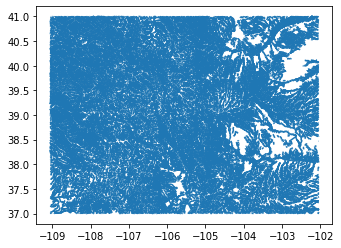

```python
# Create data frames for some data we need

# Streams of Colorado

COstreamsURL = r'https://data.colorado.gov/api/geospatial/x238-vje7?method=export&format=GeoJSON'
COstreams = gpd.read_file(COstreamsURL)

print("CRS for Colorado Streams is " + str(COstreams.crs))

COstreams.plot()
```

```
CRS for Colorado Lakes is epsg:4326
```

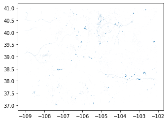

```python
# Create lakes

COlakesURL = r'https://data.colorado.gov/api/geospatial/uksn-8qya?method=export&format=GeoJSON'
COlakes = gpd.read_file(COlakesURL)

COlakes.plot()
print("CRS for Colorado Lakes is " + str(COlakes.crs))
```

```
CRS for Colorado Watersheds is epsg:4326
```

|  | id | OBJECTID | TNMID | MetaSource | SourceData | SourceOrig | SourceFeat | LoadDate | GNIS_ID | AreaAcres | ... | HUC12 | Name | HUType | HUMod | ToHUC | NonContrib | NonContr_1 | Shape_Leng | Shape_Area | geometry |
| --- | --- | --- | --- | --- | --- | --- | --- | --- | --- | --- | --- | --- | --- | --- | --- | --- | --- | --- | --- | --- | --- |
| 0 | wbdhu12.1 | 1 | {F95CAD68-5D27-4BAA-91AF-111EB3B957B3} |  |  |  |  | 2013-01-18T00:00:00 | 0 | 13730.02 | ... | 140801070105 | East Fork Mud Creek | S | TF | 140801070106 | 0.0 | 0.0 | 0.348509 | 0.005653 | MULTIPOLYGON (((-108.35734 37.43490, -108.3571... |
| 1 | wbdhu12.2 | 2 | {96FF2F88-7450-468F-8097-91E853F3DCD2} |  |  |  |  | 2013-01-18T00:00:00 | 0 | 7939.74 | ... | 140801070101 | Middle Mancos River | S | NM | 140801070104 | 0.0 | 0.0 | 0.281561 | 0.003270 | MULTIPOLYGON (((-108.16511 37.42925, -108.1648... |
| 2 | wbdhu12.3 | 3 | {CAE937F8-F661-4223-9F00-9CE9275BCA54} |  |  |  |  | 2013-01-18T00:00:00 | 0 | 27377.13 | ... | 140801070102 | West Mancos River | S | GC,TF | 140801070104 | 0.0 | 0.0 | 0.574880 | 0.011280 | MULTIPOLYGON (((-108.13119 37.49459, -108.1304... |
| 3 | wbdhu12.4 | 4 | {36248722-4C00-4886-9690-F90AB2962AF5} |  |  |  |  | 2013-01-18T00:00:00 | 0 | 16503.55 | ... | 140801070103 | Chicken Creek | S | GC,IT,TF | 140801070104 | 0.0 | 0.0 | 0.592836 | 0.006798 | MULTIPOLYGON (((-108.17225 37.49737, -108.1715... |
| 4 | wbdhu12.5 | 5 | {741A1A49-F077-4918-8829-75274F6685A8} |  |  |  |  | 2013-01-18T00:00:00 | 0 | 15887.92 | ... | 140801070104 | Upper Mancos Valley-Mancos River | S | NM | 140801070108 | 0.0 | 0.0 | 0.689548 | 0.006540 | MULTIPOLYGON (((-108.09096 37.42879, -108.0901... |

5 rows × 22 columns

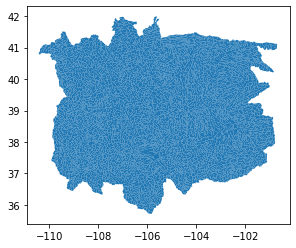

```python
# Create watersheds

COwsURL = r'https://geo.colorado.edu/download/file/47540-5ca269dcbfd55f000a1af25b-geojson.json'
COws = gpd.read_file(COwsURL)

COws.plot()
print("CRS for Colorado Watersheds is " + str(COws.crs))
COws.head()
```

## Now let's download a few zip files containing data we need

#### go go gadget *BAER burn severity* data and *Colorado DEM* data

```python
# Now... we are looking at all of the streams, lakes, and watersheds in the entire state of Colorado
# Seems like that scope may be a bit excessive for a wildfire - even a big one...
# Let's make a project boundary!!! (source: https://fsapps.nwcg.gov/baer/baer-imagery-support-data-download))

# to do this, we need to:
# (1) make a new data folder
# (2) download zips for burn severity data from the BAER website and NED data
# (3) unzip files
```

```python
# (1) This will create a new folder

zipfiles = "zipfiles"
zippath = "zipcontents"
reports = "datareports"
newdata = "newlayers"

try:
    os.mkdir(zippath)
except OSError:
    print ("New folder creation for %s failed!!!" % zipfiles)
else:
    print ("Successfully created a folder for your .zip files , called %s " % zipfiles)

try:
    os.mkdir(zipfiles)
except OSError:
    print ("New folder creation for %s failed!!!" % zippath)
else:
    print ("Successfully created a folder for your zip data, called %s " % zippath)


try:
    os.mkdir(newdata)
except OSError:
    print ("New folder creation for %s failed!!!" % newdata)
else:
    print ("Successfully created a folder for additional layers you will create, called %s " % newdata)

try:
    os.mkdir(reports)
except OSError:
    print ("New folder creation for %s failed!!!" % reports)
else:
    print ("Successfully created a folder for reports we will print later, called %s " % reports)
```

```
New folder creation for zipfiles failed!!!
New folder creation for zipcontents failed!!!
New folder creation for newlayers failed!!!
New folder creation for datareports failed!!!
```

```python
# (2) This downloads the zipped preliminary burn severity data from the USFS BAER site
# so that we can use the layers in our project!

zipurl = r'https://fsapps.nwcg.gov/baer/sites/baer/files/cameronpeak_co_preliminary_20200913.zip'
DEMurl = r'https://www.coloradoview.org/wp-content/coloradoviewData/aerial/dem-4-4.zip'

#files to be created
BAERzip = os.path.join(zipfiles, 'BAERdata.zip')
DEMzip = os.path.join(zipfiles, 'DEMdata.zip')

r = requests.get(zipurl, allow_redirects=True)
r2 = requests.get(DEMurl, allow_redirects=True)


open(BAERzip, 'wb').write(r.content)
open(DEMzip, 'wb').write(r2.content)
```

```
57294231
```

```python
# (3) This unzips the downloaded data into the "zipcontents" folder we created

with zipfile.ZipFile(BAERzip, 'r') as zip_ref:
    zip_ref.extractall(zippath)

with zipfile.ZipFile(DEMzip, 'r') as zip_ref:
    zip_ref.extractall(zippath)
```

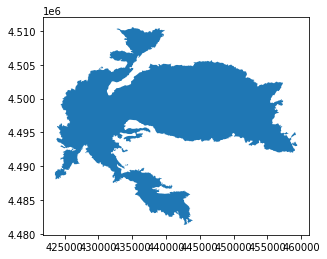

```python
# Great!  Now we can bring in our freshly downloaded burn boundary layer
# We will deal with elevation a little later

burnpath = os.path.join(zippath, "co4060910587920200813_20200809_20200913_burn_bndy_utm.shp")
burnbound = gpd.read_file(burnpath)


burnbound.plot()
```

```python
# We need to identify affected watersheds, including their respective streams and lakes
# that may have been affected by the fire.

# First, we need to make sure all dataframes are in the same CRS
# We will use the CRS for the burn boundary as our reference CRS

print("The CRS for burn boundary is " + str(burnbound.crs))
```

```
The CRS for burn boundary is epsg:26913
```

```python
if COlakes.crs != burnbound.crs:
    print("Uhoh! CRS mismatch between lakes and buffered boundary... let's fix that.")
    COlakes = COlakes.to_crs(burnbound.crs)
    print("COlakes CRS is fixed and is now " + str(COlakes.crs) )
else:
    print("CRS for both lakes and buffered burn boundary is a match.")

if COstreams.crs != burnbound.crs:
    print("\nUhoh! CRS mismatch between rivers and buffered boundary... let's fix that.")
    COstreams = COstreams.to_crs(burnbound.crs)
    print("COstreams CRS is fixed and is now " + str(COstreams.crs) )
else:
    print("\nCRS for both streams and buffered burn boundary is a match.")


if COws.crs != burnbound.crs:
    print("\nUhoh! CRS mismatch between watersheds and buffered boundary... let's fix that.")
    COws = COws.to_crs(burnbound.crs)
    print("COws CRS is fixed and is now " + str(COws.crs) )
else:
    print("\nCRS for both watersheds and buffered burn boundary is a match.")
```

```
Uhoh! CRS mismatch between lakes and buffered boundary... let's fix that.
COlakes CRS is fixed and is now epsg:26913

Uhoh! CRS mismatch between rivers and buffered boundary... let's fix that.
COstreams CRS is fixed and is now epsg:26913

Uhoh! CRS mismatch between watersheds and buffered boundary... let's fix that.
COws CRS is fixed and is now epsg:26913
```

### ....now clipping streams, lakes and watersheds to our area of interest....

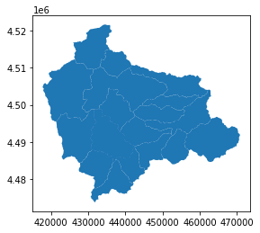

```python
# We can't just clip watersheds by the burn boundary, because we want to see the whole watershed
# that might be affected by the fire
# solution?  First make a layer of all watersheds that intersect with the fire
# unfortunately, we lose some of our pertinent data (i.e. watershed name) in this spatial join
# don't worry.... i have a plan

sheds_in_fire = gpd.sjoin(COws, burnbound, how="inner", op='intersects')
sheds_in_fire.plot()

# sheds_in_fire shows only the watersheds where some part falls within the fire
```

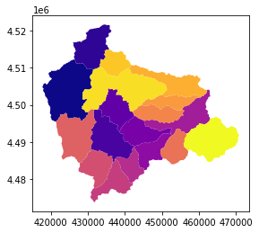

```python
# We will now clip the original CO watersheds layer by our 'sheds_in_fire'
# thereby creating a layer with the unique name of each affected watershed
# keep_geom_type = True prevents us from accidentally creating watersheds that are just boundary lines
# polygonal watersheds only, please!

sheds = gpd.clip(COws, sheds_in_fire, keep_geom_type=True)

sheds.plot(cmap='plasma')
```

```python
# Which watersheds may have been affected by the Cameron Peak Fire?

sheds_unique = sheds.Name.unique()

counter = 0

for ws in sheds_unique:
    counter = counter + 1
    print(str(counter) + ". " + ws)
```

```
1. Rawah Creek-Laramie River
2. Nunn Creek
3. Willow Creek-Cache la Poudre River
4. Sheep Creek
5. Beaver Creek
6. Headwaters South Fork Cache la Poudre River
7. Pendergrass Creek-South Fork Cache la Poudre River
8. Hague Creek
9. Headwaters Cache la Poudre River
10. La Poudre Pass Creek
11. Joe Wright Creek
12. Pennock Creek
13. Little Beaver Creek
14. Bennett Creek
15. Sevenmile Creek-Cache la Poudre River
16. Roaring Creek
17. Black Hollow-Cache la Poudre River
18. Upper Buckhorn Creek
```

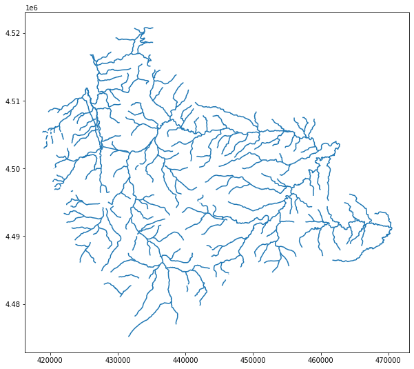

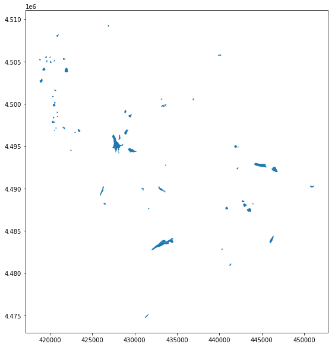

```python
# Any reservoir within the watershed may be at risk of sedimentation from erosion within the fire
# so we want to see any potentially affected streams and reservoirs
# to remedy this, we will use our new watersheds layer to clip streams and lakes


streams = gpd.clip(COstreams, sheds)
lakes = gpd.clip(COlakes, sheds)

streams.plot(figsize = (10,10))
lakes.plot(figsize = (10,10))
```

```python
# Let's save our clipped streams, lakes and watersheds layers to our new data folder, for future generations
# CPF = Cameron Peak Fire

streams.to_file(os.path.join(newdata, "CPFstreams.shp"))
lakes.to_file(os.path.join(newdata, "CPFlakes.shp"))
sheds.to_file(os.path.join(newdata, "CPFwatersheds.shp"))

print("Shapefiles for clipped streams, lakes, and watersheds have been saved to your 'new layers' folder.")
```

```
Shapefiles for clipped streams, lakes, and watersheds have been saved to your 'new layers' folder.
```

## Now let's work with our dNBR and DEM rasters!

```python
# It's raster time!
# here are the paths to:
# 1. the elevation tif (source: Geospatial Data Gateway)
# 2. DNBR burn severity tif (downloaded from BAER zip file earlier!!!)

# set variables for our rasters
elevrast = os.path.join(zippath, "4_4.tif")
burnDNBR = os.path.join(zippath, "co4060910587920200813_20200809_20200913_dnbr_utm.tif")
```

```python
# now let's open them up and take a peak at the CRS

elev = rasterio.open(elevrast)
burnsevras = rasterio.open(burnDNBR)

print("CRS for elevation is " + str(elev.crs))
print("CRS for burn severity is " + str(burnsevras.crs))
```

```
CRS for elevation is EPSG:26913
CRS for burn severity is EPSG:26913
```

```python
# let's check if these are in the same CRS

if elev.crs == burnbound.crs and burnsevras.crs == burnbound.crs:
    print("Good news, your two rasters and project area have the same CRS!")
    print("Elev CRS is " + str(elev.crs) + " and burn sev CRS is " + str(burnsevras.crs))
else:
    print("Houston, we are mismatched.")
    elev = elev.to_crs(burnbound.crs)
    burnsevras = burnsevras.to_crs(burnbound.crs)
    print("Okay... now elev CRS is " + str(elev.crs) + " and burn sev CRS is " + str(burnsevras.crs))
```

```
Good news, your two rasters and project area have the same CRS!
Elev CRS is EPSG:26913 and burn sev CRS is EPSG:26913
```

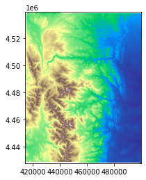

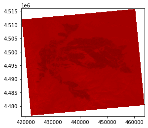

```python
# well heck, what do these things look like?

show(elev, cmap='terrain')
show(burnsevras, cmap = 'jet')
```

```python
# We need to extract by mask to cut both of these rasters down to the size of our project area
# Note: burn sev raster needs to be extracted by mask to enable reclassification into burn sev categories
```

```python
# We have to convert our mask feature (burnbound) into json format, to please the fickle rasterio gods

def getFeatures(burnbound):
    # now turning this into rasterio friendly layer
    import json
    return [json.loads(burnbound.to_json())['features'][0]['geometry']]

coords = getFeatures(burnbound)
```

```python
# now... let's mask up

# Clip the raster with burn boundary polygon
camelev, out_transform = mask(dataset=elev, shapes=coords, crop = True)
camburnsevras, out_transform = mask(dataset=burnsevras, shapes=coords, crop=True)
```

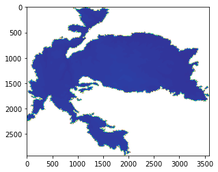

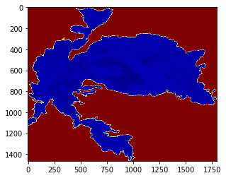

```python
# Let's take a look at how these turned out....

show(camelev, cmap = 'terrain')
show(camburnsevras, cmap = 'jet')
```

```python
#update metadata for our new baby rasters


#elev_meta=  elev.meta.copy()
burn_meta=  burnsevras.meta.copy()
elev_meta = elev.meta.copy()

burnout = os.path.join(newdata, "burnsev_clip.tif")
elevout = os.path.join(newdata, "elev_clip.tif")

# now let's save this good stuff

with rasterio.open(elevout, "w", **elev_meta) as dest:
        dest.write(camelev)
        print("A copy of your clipped elevation raster has been saved at " + elevout)
with rasterio.open(burnout, "w", **burn_meta) as dest:
        dest.write(camburnsevras)
        print("A copy of your clipped burn severity raster has been saved at " + burnout)
```

```
A copy of your clipped elevation raster has been saved at newlayers/elev_clip.tif
A copy of your clipped burn severity raster has been saved at newlayers/burnsev_clip.tif
```

## Raster reclassification time!

#### NOTE: instead of using the AGOL hosted Cam Peak burn severity vector layer I decided instead to:

1. Use the raw dNBR .tif file from the BAER zip file we downloaded earlier
2. Reclassify the dNBR file into *unburned* , *low* , *moderate* , and *high* severity burned areas
3. Polygonize the reclassified raster
4. Select out the high severity area

```python
# Time to reclassify raster into our burn severity categories

# RECLASS code adapted from an unknown user, but
# the source: http://geoexamples.blogspot.com/2013/06/gdal-performance-raster-classification.html


# To determine value cutoffs for different severity categories
# I started with the suggestions on page LA-38
# from this document: https://www.fs.fed.us/rm/pubs/rmrs_gtr164/rmrs_gtr164_13_land_assess.pdf
# and then adjusted them until it looked similar to the BAER data

classification_values = [-692,100,500,800, 1130] #The interval values to classify
classification_output_values = [1,2,3,4,0] #The value assigned to each interval


in_file = burnout

#out file

burnreclass = os.path.join(newdata, "burnsev_reclassed.tif")

ds = gdal.Open(in_file)
band = ds.GetRasterBand(1)

block_sizes = band.GetBlockSize()
x_block_size = block_sizes[0]
y_block_size = block_sizes[1]

xsize = band.XSize
ysize = band.YSize

max_value = band.GetMaximum()
min_value = band.GetMinimum()

if max_value == None or min_value == None:
    stats = band.GetStatistics(0, 1)
    max_value = stats[1]
    min_value = stats[0]

format = "GTiff"
driver = gdal.GetDriverByName( format )
dst_ds = driver.Create(burnreclass, xsize, ysize, 1, gdal.GDT_Byte )
dst_ds.SetGeoTransform(ds.GetGeoTransform())
dst_ds.SetProjection(ds.GetProjection())

for i in range(0, ysize, y_block_size):
    if i + y_block_size < ysize:
        rows = y_block_size
    else:
        rows = ysize - i
    for j in range(0, xsize, x_block_size):
        if j + x_block_size < xsize:
            cols = x_block_size
        else:
            cols = xsize - j

        data = band.ReadAsArray(j, i, cols, rows)
        r = zeros((rows, cols), numpy.uint8)

        for k in range(len(classification_values) - 1):
            if classification_values[k] <= max_value and (classification_values[k + 1] > min_value ):
                r = r + classification_output_values[k] * logical_and(data >= classification_values[k], data < classification_values[k + 1])
        if classification_values[k + 1] < max_value:
            r = r + classification_output_values[k+1] * (data >= classification_values[k + 1])

        dst_ds.GetRasterBand(1).WriteArray(r,j,i)

dst_ds = None
```

```python
# This polygonizing code block adapted from Penn State
# https://www.e-education.psu.edu/geog489/node/2215

raster = gdal.Open(burnreclass)
raster.RasterCount
band = raster.GetRasterBand(1)

burnpoly = os.path.join(newdata, "burnsev_reclass_poly.shp")

drv = ogr.GetDriverByName('ESRI Shapefile')
outfile = drv.CreateDataSource(burnpoly)
outlayer = outfile.CreateLayer('polygonized raster', srs = None )
newField = ogr.FieldDefn('DN', ogr.OFTReal)
outlayer.CreateField(newField)


# Once the shapefile is prepared, we call Polygonize(...)
# and provide the band and the output layer as parameters plus a few additional parameters needed:


gdal.Polygonize(band, None, outlayer, 0, [])
outfile = None
```

```python
# loading polygonized raster into a geopandas dataframe

burnpolygeo = gpd.read_file(burnpoly)
```

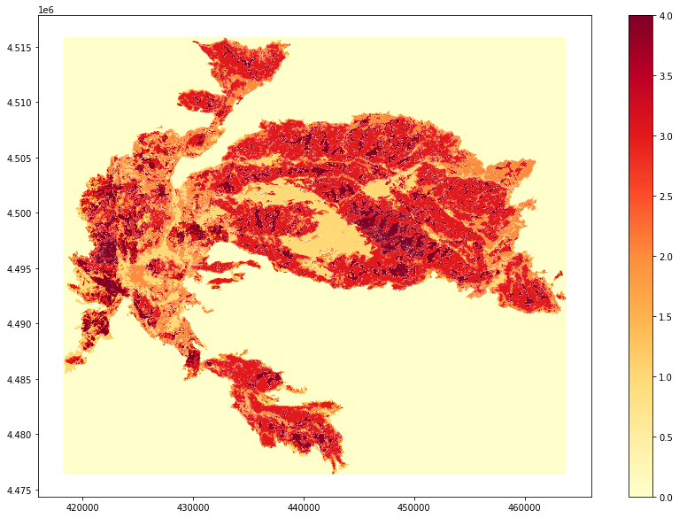

```python
burnpolygeo.plot(column="DN", cmap= "YlOrRd", legend=True, figsize=(15,10))
```

```python
print(burnpolygeo.crs)
```

```
None
```

```python
# Welp.  We need matching CRS with other layers before we can proceed

burnpolygeo = burnpolygeo.set_crs(burnbound.crs)

print(burnpolygeo.crs)
burnpolygeo.to_file(os.path.join(newdata, "BurnSeverityCategories.shp"))
print("A new shapefile showing categorized burn severity has been saved to your 'newlayers' folder.")
```

```
epsg:26913
A new shapefile showing categorized burn severity has been saved to your 'newlayers' folder.
```

```python
# Let's select out a new layer that is only High Severity (DN = 4.0)

highsev = burnpolygeo[burnpolygeo.DN == 4.0]
highsev.to_file(os.path.join(newdata, "HighSevBurnedArea.shp"))
print("A new shapefile showing high severity burned area has been saved to your 'newlayers' folder.")
```

```
A new shapefile showing high severity burned area has been saved to your 'newlayers' folder.
```

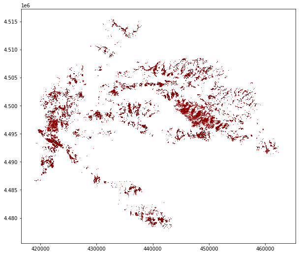

```python
# Now let's see how it looks!

highsev.plot(facecolor = "DarkRed", figsize =(10,15))
```